# Зелимхан Гудиев. Лабораторная №1

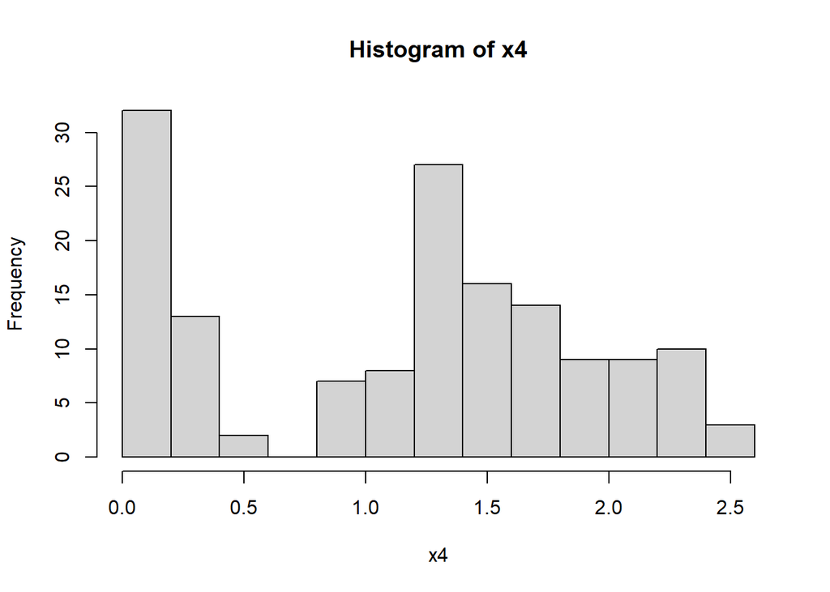

```r
hist(x4)
```

попарной матрицы диаграмм рассеяния:

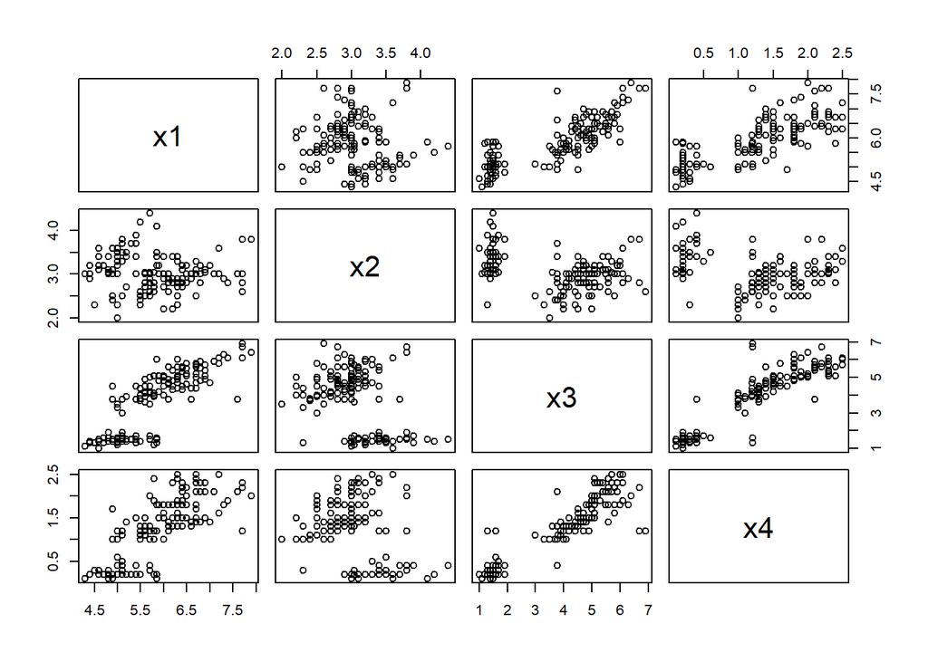

```r
 pairs(~ x1 + x2 + x3 + x4)
```

тепловой диаграммы:

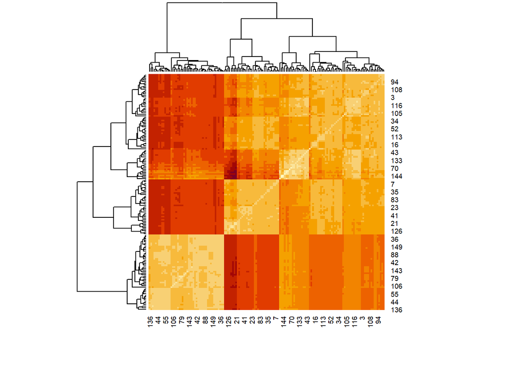

```r
distMatrix <- as.matrix(dist(myData[, 1:4]))
heatmap(distMatrix)
```

уровневой диаграммы

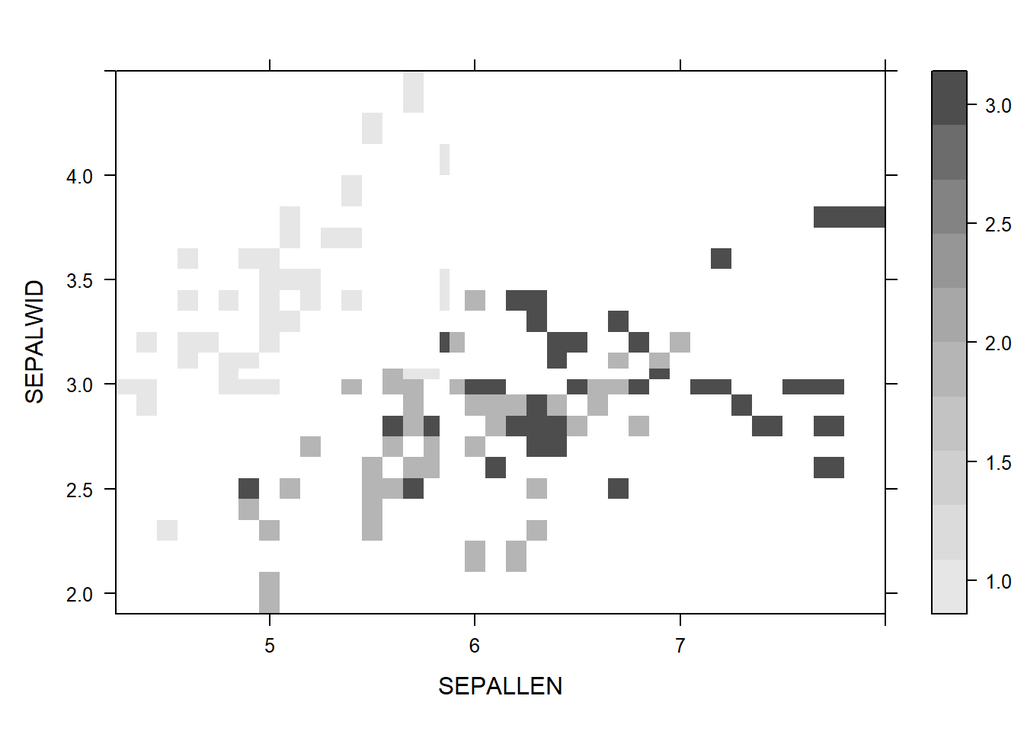

```r
library(lattice)
myData[, 5] <- as.factor(myData[, 5])
levelplot(IRISTYPE ~ SEPALLEN * SEPALWID, myData, cuts = 9, col.regions = grey.colors(10)[10:1])
```

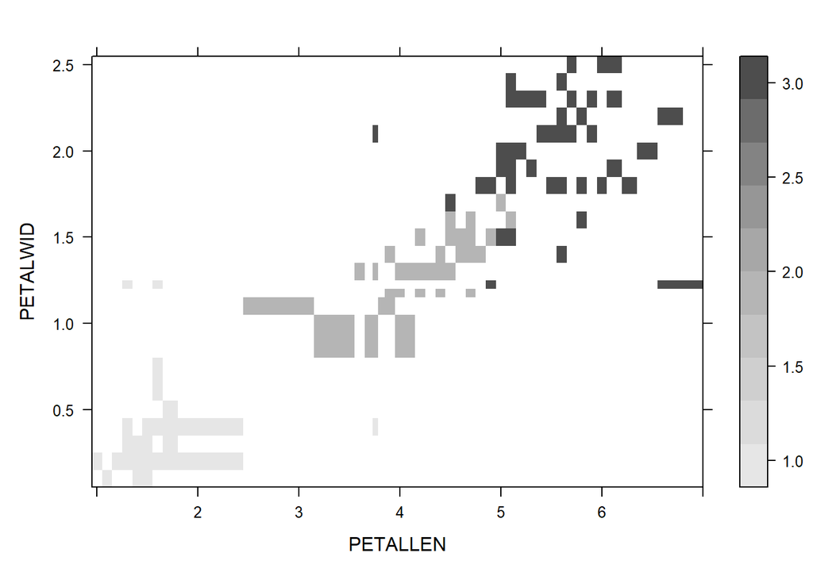

```r
levelplot(IRISTYPE ~ PETALLEN * PETALWID, myData, cuts = 9, col.regions = grey.colors(10)[10:1])
```

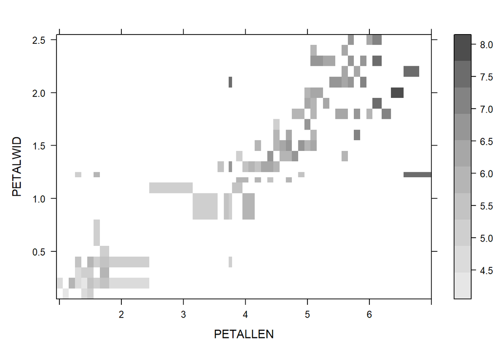

```r
levelplot(SEPALLEN ~ PETALLEN * PETALWID, myData, cuts = 9, col.regions = grey.colors(10)[10:1])
```

контурной диаграммы (диаграммы высот) (также в библиотеке lattice)

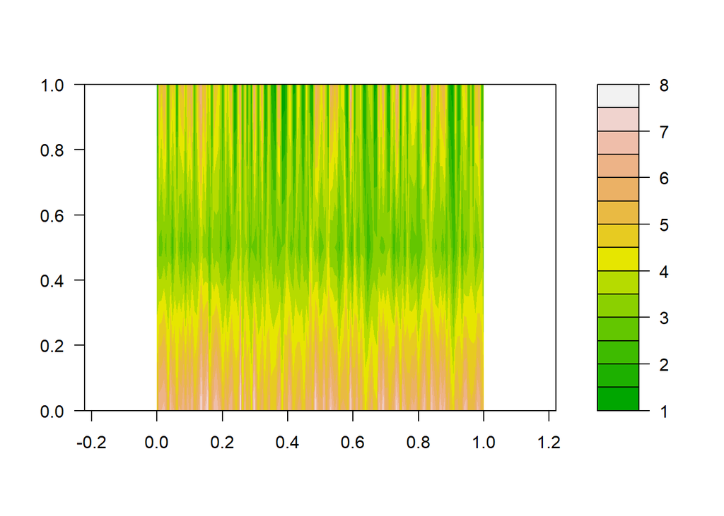

```r
filled.contour(as.matrix(myData[, 1:3]), color=terrain.colors, asp=1
               #, plot.axes=contour(as.factor(myData[, 1:4]), add=T)
               )
```

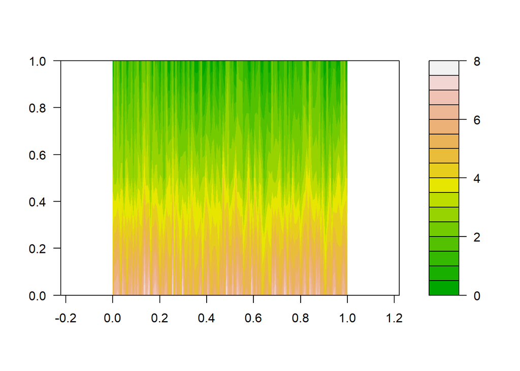

```r
filled.contour(as.matrix(myData[, c(1, 2, 4)]), color=terrain.colors, asp=1
               #, plot.axes=contour(as.factor(myData[, 1:4]), add=T)
               )
```

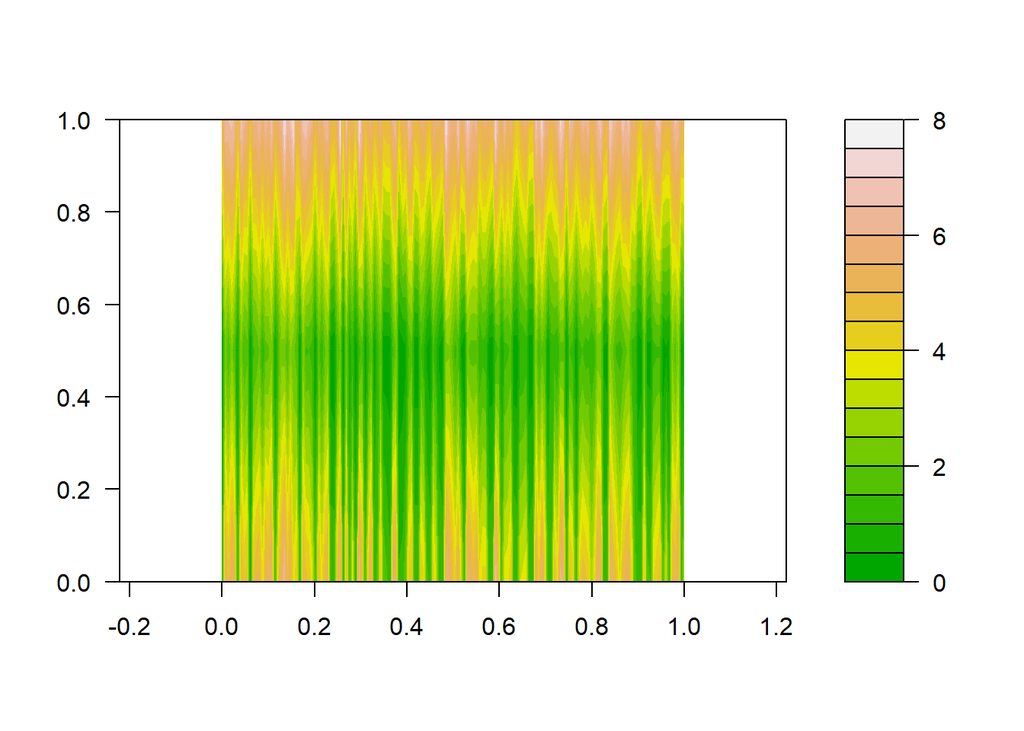

```r
filled.contour(as.matrix(myData[, c(3, 4, 1)]), color=terrain.colors, asp=1
               #, plot.axes=contour(as.factor(myData[, 1:4]), add=T)
               )
```

[figure not shown]

```r
filled.contour(as.matrix(myData[, c(3, 4, 5)]), color=terrain.colors, asp=1
               # , plot.axes=contour(as.matrix(myData[, 3]), as.matrix(myData[, 4]), z = as.matrix(myData[, 5]), add=T)
               )
```

**Ответ:**  
*Непонятно что использовать в квчестве контура для нашего датасета, поэтому приведем код лабораторно в этом пункте без изменений.*

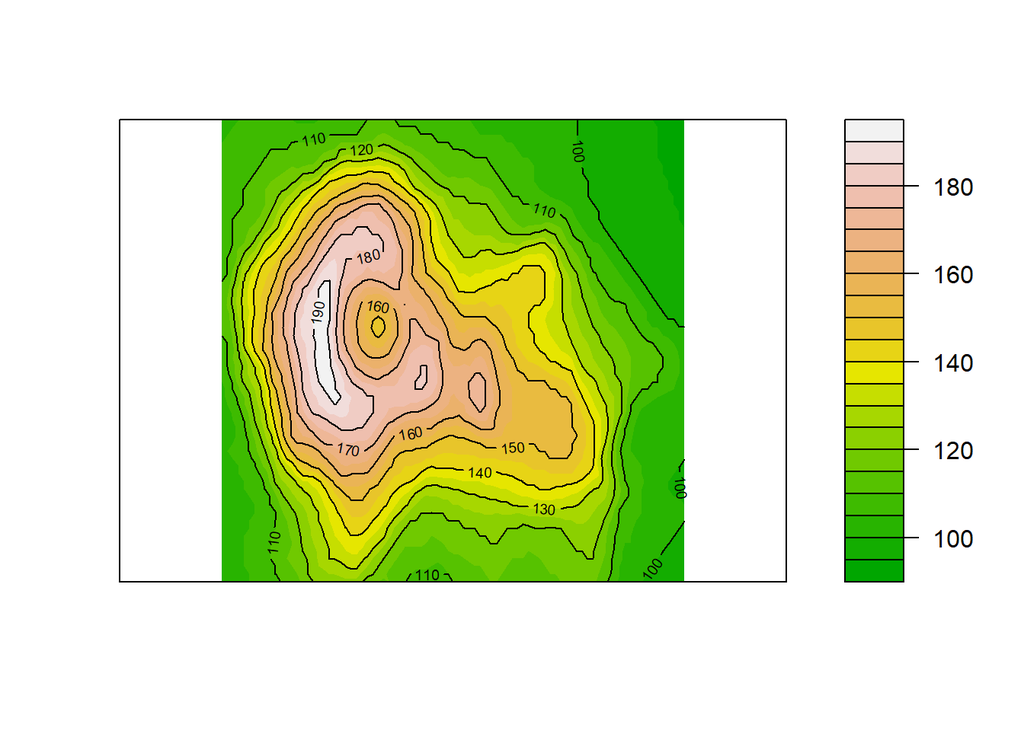

```r
filled.contour(volcano, color=terrain.colors, asp=1, plot.axes=contour(volcano, add=T))
```

поверхности многомерного распределения

**Ответ:**  
*Поскольку непонятно как представить наши данные как матрицу перепадов высот, и чем должно быть третье измерение, оставим корд без изменений.*

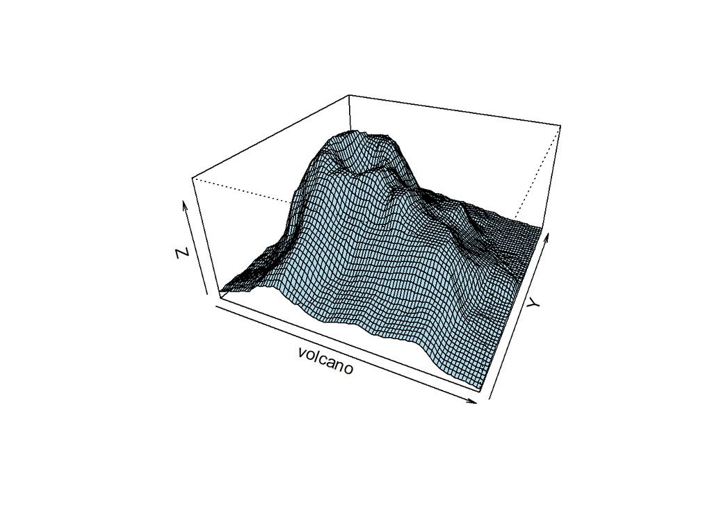

```r
persp(volcano, theta=25, phi=30, expand=0.5, col="lightblue")
```

графика параллельных координат на основе переменных #1 - 4 (по порядку слева направо из данных) в качестве числовых, и переменной #5 (IRISTYPE) в качестве группировочной (библиотека MASS).

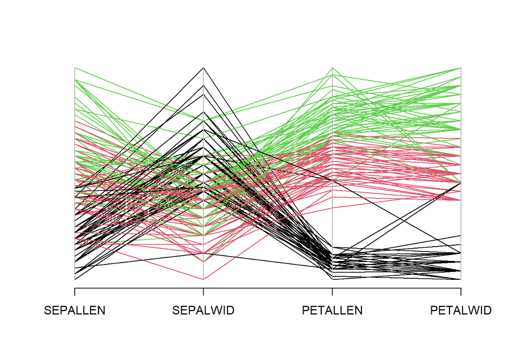

```r
library(MASS)
parcoord(myData[1:4], col = as.factor(myData[, 5]))
```

Сделайте выводы.  
Напишите аналитическую записку о том, что представляют собой имеющиеся данные, какова их структура и описательные характеристики, какие результаты получены на основе первичного анализа и обработки.  
**Выводы:** *Датасет представляет из себя таблицу с 4 количественными колонками и одной категориальной, количество наблюдений в таблице - 150. В процессе исследования датасета были обнаружены пустые значения (в 21 строке были обнаружены NA), которые было решено заполнить среднеми значениями, т.к. пустые значения находились в количественных колонках и по смыслу средний показатель по колонке частично компненсирует упущенную информацию. Также были обнаружены экстремальные значения в колонке SEPALWID, 3 значения которые выходят за 1.5*IQR от Q3 и одно значение, выходящее за 1.5*IQR от Q1. Были подсчитаны винзорированные(триммированные) средние, которые не сильно отличались от средних со всеми элементами, что говорит о незначительном влиянии выбросов и крайних значений на статистики в нашем датасете. Также выбросы, в которых участвую сразу несколько признаков, были исследованы с помощью метода К-средних, были обнаружены 5 значений наиболее удаленных от центров получившихся кластеров.Также в процессе кластеризации и визуализации данных было выявлено, что классы наиболее разделимы по признакам PETALLEN и PETALWID.*